# A League Of Legends Champion Synergy Analysis

###### 5/12/21

## Introduction

League of Legends (or commonly refered to as League for short) was created ten years ago by Riot Games and has over 50 million daily active users. This makes it the most popular PC game of all time and it is played casually and competively all over the world. Given its popularity there is also a huge esports scene and many are even pushing for esports and league specfically to be added to the olympics. I personally have played league on and off for over 5 years and although there is a very high learning curve, it can be toxic, and is quite addicting I have enjoyed my time playing this game like many others. Given that is a team based game where 10 players in a 5v5 format select between 138 unique champions, (characters) certain synergies have risen based on their abilties working well together. I want to take a look at some of the best synergies from our dataset and the most popular synergies in the League community. I will investigate the winrate of these synergies and if these synergies work best in early game or late game team compositons.

##### Motivation

There are a few reasons why this information would be valuable, but I will describe a couple. If you are a player trying rank up it would be improtant to know when to pick which synergies depending on if your composition plays for early or late game. If you are a esports player/coach it is important to understand what kind of composition the you or the enemy is picking based on the synergies.

## Background

League of Legends is very complicated game. I will try to define the relevant terms to this project below, but if you want to read more about it here is a [link](https://www.mobafire.com/league-of-legends/build/fundamentals-league-of-legends-new-player-beginner-guide-371292).

- Seasons: Seasons refers to an interval of League of Legends defined by Riot Games. Major changes like new champions, reworks, and new items occur between seasons and they change annualy.
- Patches: In each season there are many patches that cause minor changes to the game like buffs and nerfs.
- Meta: Based on the current season and patch certain champions will be stronger than others. What is currently strong is refered to as the current meta.
- Champions: A champions is just a selectable character. At the time of the dataset there are 138 champions for each player to choose from at the start of the game.
- Champion Kits: A champion has a kit which just corresponds to their abilities.
- Rank: League is a competitive game and has a ranking system. This varies from bronze all the way up to challenger. Players play games to climb up the ranks.
- Crowd Control (CC): Crowd control refers to immobilizing effects like slows, stuns, and knockups.
- Chain CC: Chain CC is when these crowd control effects are chained together.
- Solo/Duo Lanes: There are 5 roles on each team. They are top lane, mid lane, support, attack damage carry and junguler. To make things simpiler I do not talk about positions except for the general categories solo lanes and duo lanes. A solo lane is like top and mid lane as you are the only person on your team in that lane. A duo lane is like bot lane where both the attack damage carry and support rescind. To make things simple just understand that you are in your lane during the early game.
- Strong/Weak Champions and Synergies: Often champions or synergies will be refered to as strong or weak. This is based on the meta and people define if a champion/synergy is strong or weak by their winrate in that patch. I will also be using this logic.
- Early game and Late game: League is a dynamic game and depending on the time of the game you are meant to be doing different things. I will refrain from discussing what these are as it is not needed, but I will make a simple distinction between early game (the beginning of the game) and late game (the end of the game). In the early game players are in their assigned lanes which means it is 1v1s and 2v2s depending on if it is a solo lane or duo lane. In the late game players teamfight which is a 5v5 battle.
- Team Composition: Each team has 5 players. There composition is the 5 champions each player selected. Compositions can be drafted for a variety of strategies including playing for early game, late game, or even teamfights.

## Data Scraping

First we will import all of the necessary libraries.

```python
import pandas as pd
import numpy as np
import matplotlib.pyplot as plt
import datetime
import sklearn
from sklearn.linear_model import LinearRegression
from sklearn import linear_model
import json
import pprint
import math
```

##### Source

Our dataset is from Kaggle ([Link](https://www.kaggle.com/datasnaek/league-of-legends)) and includes over 50,000 ranked games from the European West (EUW) server. The author used the Riot Games api which I unfortunately was having issues accessing. The data is stored in a csv file and has corresponding json files that contain a way to convert between champion and summoner spell IDs and their names. Some important things to note about the dataset.

1. This dataset is from season 7 of league. Currently League is in season 11 for reference.
2. There is no mention of the ranks of these games. This is important to keep in mind because what is good in the best rank could be terrible in the worst rank.
3. There is no missing data.
4. Since these are ranked games a champion can only occur once in any game.

We will read the csv file into a pandas dataframe.

```python
# Reads the downloaded csv file into a pandas dataframe
pd.set_option('display.max_columns', None)
pd.options.mode.chained_assignment = None
original_df = pd.read_csv("games.csv")
original_df.head()
```

|  | gameId | creationTime | gameDuration | seasonId | winner | firstBlood | firstTower | firstInhibitor | firstBaron | firstDragon | firstRiftHerald | t1_champ1id | t1_champ1_sum1 | t1_champ1_sum2 | t1_champ2id | t1_champ2_sum1 | t1_champ2_sum2 | t1_champ3id | t1_champ3_sum1 | t1_champ3_sum2 | t1_champ4id | t1_champ4_sum1 | t1_champ4_sum2 | t1_champ5id | t1_champ5_sum1 | t1_champ5_sum2 | t1_towerKills | t1_inhibitorKills | t1_baronKills | … |
| --- | --- | --- | --- | --- | --- | --- | --- | --- | --- | --- | --- | --- | --- | --- | --- | --- | --- | --- | --- | --- | --- | --- | --- | --- | --- | --- | --- | --- | --- | --- |
| 0 | 3326086514 | 1504279457970 | 1949 | 9 | 1 | 2 | 1 | 1 | 1 | 1 | 2 | 8 | 12 | 4 | 432 | 3 | 4 | 96 | 4 | 7 | 11 | 11 | 6 | 112 | 4 | 14 | 11 | 1 | 2 | … |
| 1 | 3229566029 | 1497848803862 | 1851 | 9 | 1 | 1 | 1 | 1 | 0 | 1 | 1 | 119 | 7 | 4 | 39 | 12 | 4 | 76 | 4 | 3 | 10 | 4 | 14 | 35 | 4 | 11 | 10 | 4 | 0 | … |
| 2 | 3327363504 | 1504360103310 | 1493 | 9 | 1 | 2 | 1 | 1 | 1 | 2 | 0 | 18 | 4 | 7 | 141 | 11 | 4 | 267 | 3 | 4 | 68 | 4 | 12 | 38 | 12 | 4 | 8 | 1 | 1 | … |
| 3 | 3326856598 | 1504348503996 | 1758 | 9 | 1 | 1 | 1 | 1 | 1 | 1 | 0 | 57 | 4 | 12 | 63 | 4 | 14 | 29 | 4 | 7 | 61 | 4 | 1 | 36 | 11 | 4 | 9 | 2 | 1 | … |
| 4 | 3330080762 | 1504554410899 | 2094 | 9 | 1 | 2 | 1 | 1 | 1 | 1 | 0 | 19 | 4 | 12 | 29 | 11 | 4 | 40 | 4 | 3 | 119 | 4 | 7 | 134 | 7 | 4 | 9 | 2 | 1 | … |

## Data Tidying

There is way too much irrelvant data for our analysis in the table so we need to first drop all the rows we do not care about

```python
# Grabs only the game duration, winner and the champions of each teams columns
tidy_df = original_df[["gameDuration", "winner", "t1_champ1id", "t1_champ2id", "t1_champ3id", "t1_champ4id", "t1_champ5id", "t2_champ1id", "t2_champ2id", "t2_champ3id", "t2_champ4id", "t2_champ5id"]]
tidy_df.head()
```

|  | gameDuration | winner | t1_champ1id | t1_champ2id | t1_champ3id | t1_champ4id | t1_champ5id | t2_champ1id | t2_champ2id | t2_champ3id | t2_champ4id | t2_champ5id |
| --- | --- | --- | --- | --- | --- | --- | --- | --- | --- | --- | --- | --- |
| 0 | 1949 | 1 | 8 | 432 | 96 | 11 | 112 | 104 | 498 | 122 | 238 | 412 |
| 1 | 1851 | 1 | 119 | 39 | 76 | 10 | 35 | 54 | 25 | 120 | 157 | 92 |
| 2 | 1493 | 1 | 18 | 141 | 267 | 68 | 38 | 69 | 412 | 126 | 24 | 22 |
| 3 | 1758 | 1 | 57 | 63 | 29 | 61 | 36 | 90 | 19 | 412 | 92 | 22 |
| 4 | 2094 | 1 | 19 | 29 | 40 | 119 | 134 | 37 | 59 | 141 | 38 | 51 |

Now I need to use the provided JSON file to convert the champion IDs to the corresponding champions name. I will create a dictionary from the JSON file called champ_dict where I can simply index in with champion ID to get the name.

```python
# Loads the JSON file into champ_dict
with open('champion_info.json') as file:
    champ_dict = json.load(file)

# Only care about the actual data from the JSON file
champ_dict = champ_dict['data']
```

Now I can replace all the champion IDs in the dataframe with the actual names

```python
# First need to make all champion columns type strings
for i in range (1,6):
    tidy_df['t1_champ' + str(i) + 'id'] = tidy_df['t1_champ' + str(i) + 'id'].astype(str)
    tidy_df['t2_champ' + str(i) + 'id'] = tidy_df['t2_champ' + str(i) + 'id'].astype(str)

# Iterate through the entire dataframe row by row
for index, row in tidy_df.iterrows():
    # Avoids code duplication as we are doing the same thing for each player
    for i in range (1,6):
        tidy_df.at[index, 't1_champ' + str(i) + 'id'] = champ_dict[str(tidy_df.at[index, 't1_champ' + str(i) + 'id'])]['name']
        tidy_df.at[index, 't2_champ' + str(i) + 'id'] = champ_dict[str(tidy_df.at[index, 't2_champ' + str(i) + 'id'])]['name']

# Renames columns
tidy_df = tidy_df.rename(columns = {"t1_champ1id" : "t1_champ1", "t1_champ2id": "t1_champ2", "t1_champ3id": "t1_champ3", "t1_champ4id" : "t1_champ4", "t1_champ5id" : "t1_champ5", "t2_champ1id": "t2_champ1", "t2_champ2id": "t2_champ2", "t2_champ3id": "t2_champ3", "t2_champ4id": "t2_champ4", "t2_champ5id": "t2_champ5"})

tidy_df.head()
```

|  | gameDuration | winner | t1_champ1 | t1_champ2 | t1_champ3 | t1_champ4 | t1_champ5 | t2_champ1 | t2_champ2 | t2_champ3 | t2_champ4 | t2_champ5 |
| --- | --- | --- | --- | --- | --- | --- | --- | --- | --- | --- | --- | --- |
| 0 | 1949 | 1 | Vladimir | Bard | Kog'Maw | Master Yi | Viktor | Graves | Xayah | Darius | Zed | Thresh |
| 1 | 1851 | 1 | Draven | Irelia | Nidalee | Kayle | Shaco | Malphite | Morgana | Hecarim | Yasuo | Riven |
| 2 | 1493 | 1 | Tristana | Kayn | Nami | Rumble | Kassadin | Cassiopeia | Thresh | Jayce | Jax | Ashe |
| 3 | 1758 | 1 | Maokai | Brand | Twitch | Orianna | Dr. Mundo | Malzahar | Warwick | Thresh | Riven | Ashe |
| 4 | 2094 | 1 | Warwick | Twitch | Janna | Draven | Syndra | Sona | Jarvan IV | Kayn | Kassadin | Caitlyn |

## A look at Synergy Winrates

##### Grabbing Data

Now lets create a dictionary of all the individual champion winrates. Remember each champion can only occur once in any game since these are ranked games.

```python
# In the end each champion will point to its winrate.
# To get the winrates we will go through the dataframe and keep track of every game a champion is in and
# every game a champion wins. We will then simply divide these values
winrates = {}

# Iterate through the entire dataframe row by row
for index, row in tidy_df.iterrows():
    # Avoids code duplication as we are doing the same thing for each player and team
    for team in range(1,3):
        for i in range (1,6):
            currChamp = tidy_df.at[index, 't' + str(team) + '_champ' + str(i)]

            # if the champion in question is already in the dictionary
            if (currChamp in winrates):
                totalWins = winrates[currChamp][0]
                totalGames = winrates[currChamp][1]

                # if the champion won the game
                if (tidy_df.at[index, 'winner'] == team):
                    winrates[currChamp] = (totalWins + 1, totalGames + 1)
                # if the champion lost the game
                else:
                    winrates[currChamp] = (totalWins, totalGames + 1)

            # if the champion in question is not in the dictionary yet
            else:
                # if the champion won the game
                if (tidy_df.at[index, 'winner'] == team):
                    winrates[currChamp] = (1, 1)
                # if the champion lost the game
                else:
                    winrates[currChamp] = (0, 1)

# Now winrates holds a tuple of 2 elements where the first element is the number of wins and the second is the total
# number of games played for that champion. If we simply divide the two we will have our winrates
for key, value in winrates.items():
    winrates[key] = float(value[0])/float(value[1])

pprint.pprint(winrates)
```

```
{'Aatrox': 0.4701195219123506,
 'Ahri': 0.5216909436352122,
 'Akali': 0.5032214309935571,
 'Alistar': 0.49597238204833144,
 'Amumu': 0.509515570934256,
 'Anivia': 0.5359680284191829,
 'Annie': 0.5025938358254501,
 'Ashe': 0.4769059543683918,
 'Aurelion Sol': 0.525564803804994,
 'Azir': 0.43359375,
 'Bard': 0.4781676935440664,
 'Blitzcrank': 0.5120490725865342,
 'Brand': 0.5149638802889577,
 'Braum': 0.5101495726495726,
 'Caitlyn': 0.4697461629279811,
 'Camille': 0.48038176033934255,
 'Cassiopeia': 0.48879248011569054,
 "Cho'Gath": 0.5267065868263473,
 'Corki': 0.46467946100449165,
 'Darius': 0.5166923472008218,
 'Diana': 0.5151023059434882,
 'Dr. Mundo': 0.49968091895341415,
 'Draven': 0.5010824640818736,
 'Ekko': 0.4989724619810933,
 'Elise': 0.4921365554276947,
 'Evelynn': 0.4777227722772277,
 'Ezreal': 0.4644931609518456,
 'Fiddlesticks': 0.49568717653824035,
 'Fiora': 0.49740090968161144,
 'Fizz': 0.48904267589388695,
 'Galio': 0.46779536253220466,
 'Gangplank': 0.49143672692673646,
 'Garen': 0.530952992550732,
 'Gnar': 0.4941356450790413,
 'Gragas': 0.4905043586550436,
 'Graves': 0.47368421052631576,
 'Hecarim': 0.5094905094905094,
 'Heimerdinger': 0.4833134684147795,
 'Illaoi': 0.48717948717948717,
 'Irelia': 0.5067656045395024,
```

[output cut: 83 more lines]

```
 'Viktor': 0.47314867156585644,
 'Vladimir': 0.49110209178894787,
 'Volibear': 0.4958263772954925,
 'Warwick': 0.5159801743291745,
 'Wukong': 0.5233041070604523,
 'Xayah': 0.4980237154150198,
 'Xerath': 0.5274336283185841,
 'Xin Zhao': 0.5158705701078582,
 'Yasuo': 0.5015243902439024,
 'Yorick': 0.5399129172714079,
 'Zac': 0.4920255183413078,
 'Zed': 0.4936532507739938,
 'Ziggs': 0.5153480328577604,
 'Zilean': 0.49207443142660234,
 'Zyra': 0.4989384288747346}
```

Now lets do the same thing, but for each combination of champions (synergy). Given that there are 138 champions at the time of this dataset and each champion can have a synergy with 137 other champions there are 18,906 different syrnegies. However this counts every synergy twice so in reality there will be 9,453 syrnegies. We are going to collect the winrates for all of them. However, if any synergy was played less than 175 times it will not be included in our analysis as there is not enough data on that synergy. This leaves us with 3,697 synergies. Remember each champion can only occur once in any game since these are ranked games.

```python
# It will be easier if we build our datastructure first this time. In the end our datastucture will be a map
# where each key is a tuple of the two champions that represent the synergy that then points to their winrate.
winrates_synergy = {}

# Gets a sorted list of all the champions
list_of_champs = sorted(list(winrates.keys()))

# For each champion iterate through every champion
for i in list_of_champs:
    for j in list_of_champs:
        # If the champions are not the same and the synergy has not already been added to the dictionary
        if (i != j and ((i,j) not in winrates_synergy) and ((j,i) not in winrates_synergy)):
            # Again we will keep track of games won and total games played
            winrates_synergy[(i,j)] = (0, 0)

# Iterate through the entire dataframe row by row
for index, row in tidy_df.iterrows():
    # Avoids code duplication as we are doing the same thing for each player and team
    for team in range(1,3):
        for i in range (1,6):
            currChamp1 = tidy_df.at[index, 't' + str(team) + '_champ' + str(i)]

            # For each possible synergy we must update our dictionary
            for j in range(1,6):
                currChamp2 = tidy_df.at[index, 't' + str(team) + '_champ' + str(j)]

                # Make sure we do not do anything if we are talking about the same champion
                if (i != j):
                    # To account for the fact that only one of (i, j) and (j , i) is in synergy
                    if (currChamp1 > currChamp2):
                        temp = currChamp1
                        currChamp1 = currChamp2
                        currChamp2 = temp

                    totalWins = winrates_synergy[(currChamp1, currChamp2)][0]
                    totalGames = winrates_synergy[(currChamp1, currChamp2)][1]

                    # if the champions won the game
                    if (tidy_df.at[index, 'winner'] == team):
                        winrates_synergy[(currChamp1, currChamp2)] = (totalWins + 1, totalGames + 1)
                    # if the champions lost the game
                    else:
                        winrates_synergy[(currChamp1, currChamp2)] = (totalWins, totalGames + 1)

# Now winrates holds a tuple of 2 elements where the first element is the number of wins and the second is the total
# number of games played for that synergy. If we simply divide the two we will have our winrates.
delete = []

for key, value in winrates_synergy.items():
    if (value[1] < 175):
        # Keeps track of the synergyies to delete if less than 175 games played
        delete.append(key)
    else:
        winrates_synergy[key] = float(value[0])/float(value[1])

# Deletes the synergyies with less than 175 games played
for i in delete:
    del winrates_synergy[i]
```

##### Data Visualization and Analysis of Individual Champions and Synergy winrates

Lets start by first graphing the worst and best 10 champion winrates individually

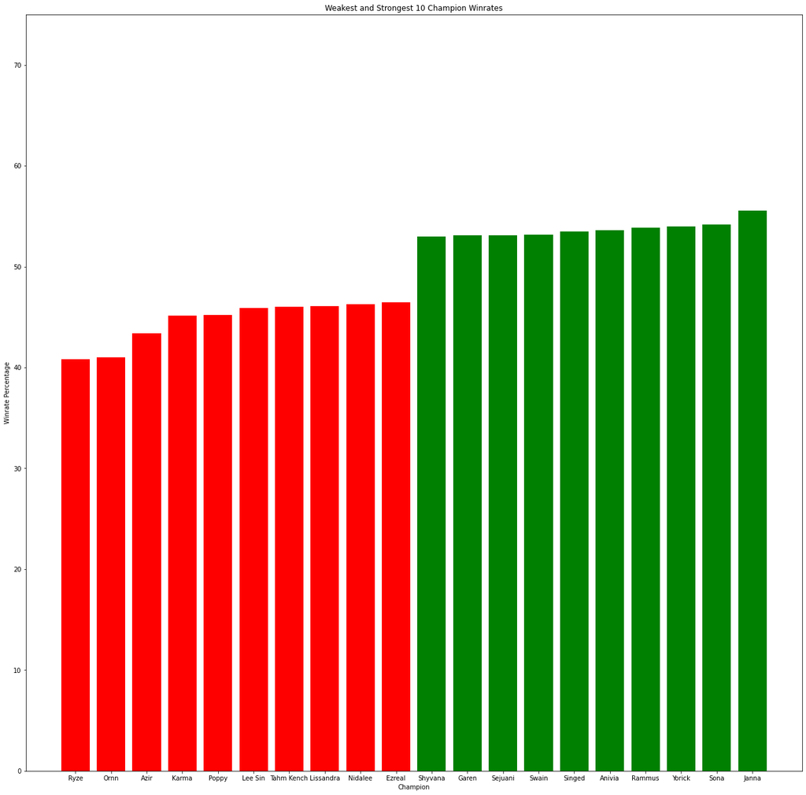

```python
# Gets all the keys in sorted order
sorted_winrate_keys = (sorted(winrates, key=winrates.get))

# Gets all the values in sorted order
sorted_winrate_values = []
for i in sorted_winrate_keys:
    sorted_winrate_values.append(winrates[i])

# Changes the values to be percentages
sorted_winrate_values = [elem * 100 for elem in sorted_winrate_values]

# Responsible for making the plot and making it look nice
fig, ax = plt.subplots(figsize=(22, 22))
ax.set_title('Weakest and Strongest 10 Champion Winrates')
plt.ylabel('Winrate Percentage')
plt.xlabel('Champion')
x = sorted_winrate_keys[0:10] + sorted_winrate_keys[len(sorted_winrate_keys)-10:len(sorted_winrate_keys)]
y = sorted_winrate_values[0:10] + sorted_winrate_values[len(sorted_winrate_values)-10:len(sorted_winrate_values)]
ax.bar(x,y, color=['red', 'red', 'red', 'red', 'red', 'red', 'red', 'red', 'red', 'red', 'green',  'green',  'green',  'green',  'green',  'green',  'green',  'green',  'green',  'green',])

plt.ylim(ymin=0, ymax = 75)
plt.show()
```

This is cool and interesting to know which champions were the worst and best in season 7, but we have not done anything new quite yet. You can simply google these statistics. Lets take a look specifically at the synergy winrates we just found above by graphing the weakest 5 synergies and the strongest 5 synergies.

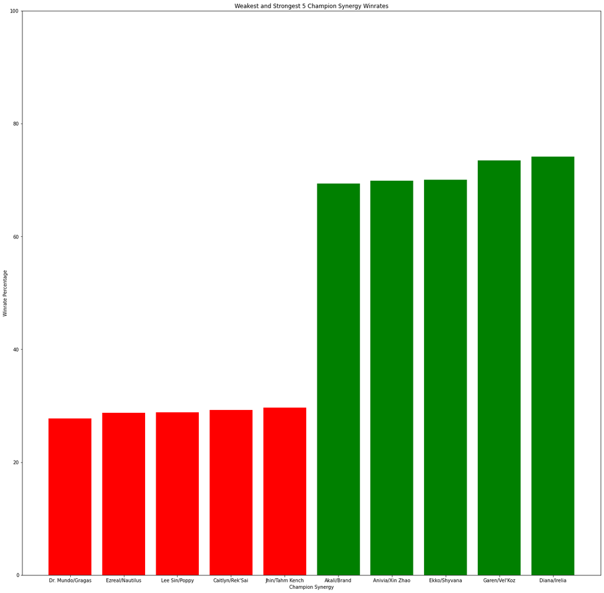

```python
# Gets all the keys in sorted order
sorted_winrate_keys = (sorted(winrates_synergy, key=winrates_synergy.get))

# Gets all the values in sorted order
sorted_winrate_values = []
for i in sorted_winrate_keys:
    sorted_winrate_values.append(winrates_synergy[i])

# Makes keys a string rather than a tuple of strings
for i in range(0,len(sorted_winrate_keys)):
    sorted_winrate_keys[i] = str(sorted_winrate_keys[i][0] + '/' + sorted_winrate_keys[i][1])

# Changes the values to be percentages
sorted_winrate_values = [elem * 100 for elem in sorted_winrate_values]

# Responsible for making the plot and making it look nice
fig, ax = plt.subplots(figsize=(22, 22))
ax.set_title('Weakest and Strongest 5 Champion Synergy Winrates')
plt.ylabel('Winrate Percentage')
plt.xlabel('Champion Synergy')
x = sorted_winrate_keys[0:5] + sorted_winrate_keys[len(sorted_winrate_keys)-5:len(sorted_winrate_keys)]
y = sorted_winrate_values[0:5] + sorted_winrate_values[len(sorted_winrate_values)-5:len(sorted_winrate_values)]
ax.bar(x,y, color=['red', 'red', 'red', 'red', 'red',  'green',  'green',  'green',  'green',  'green'])

plt.ylim(ymin=0, ymax=100)
plt.show()
```

1. Ezreal -> 46.4% and Nautilus -> 48.5%.  
   Ezreal and Nautilus are generally picked in a duo lane together, but they want to acheive exact opposite things in this lane. Ezreal wants to poke enemies and scale to the later game without falling behind while Nautilus wants to engage and kill the enemy to snowball. These differences could likely be the reason why the duo does not perform well together.
2. Diana -> 51.5% and Irelia -> 50.7% Diana and Irelia are each solo laners. They both want to snowball by assasianating there lane opponent and snowballing their leads. In the later stage of the game they both want to dive the enemy carries. These similarties could be why despite just having good individual winrates they have the highest synergy winrate.

Now the worst and best synergies are interesting, but I would like to look at some of the most popular synergies among the League community. These synergies are popular soley based on how well their kits work together and not their current strength in the meta. The ones I will be focusing are has follows with explanations of why they are particularly iteresting, but it is ok if you do not understand why the champions kits work or do not work well together. .

1. Caitlyn/Morgana: These champions are in a duo lane together. Morgana's root lasts a ridiculous amount of time. This makes it very easy for Caitlyn to place a trap on the rooted target to root for them for even longer. This coupled with Morgana being able to also ult the target for a stun after a few seconds lead to a very strong and frustrating lane to go against that many find too strong.
2. Master Yi/Taric: These champions work extremely well together because Master Yi is akin to a glass cannon being able to do insane amounts of damage but can easily be killed. Tarics ultimate gives him the ability to make a champion invunerable for a short amount of time. This means Taric can make Master Yi invunerable and he can deal his damage with no risk and very little counterplay. In fact, cheese/funnel strategies have even risen from this synergy that I will [Link](https://www.mobafire.com/league-of-legends/build/s11-taric-funnel-guide-572809).
3. Rakan/Xayah: These champions were released together and even have special abilities when they play with each other in the same game. They are the only champions in League that have built in synergy and were released in season 7.
4. Malphite/Yasuo: Malphites ultimate is a point and click area of effect knockup. Yasuo's ultimate slams knocked up targets back into the ground for insane amounts of damage and crowd control. These two champions can win teamfights by themselves.
5. Ashe/Zyra: Ashe and Zyra have absolute ton of CC ranging from slows to knockups. Given all of these tools they can both easily engange and disengange while bursting targets down or kiting and poking them out. Just an all around hard duo lane to handle.

Lets first graph the winrates of these synergies.

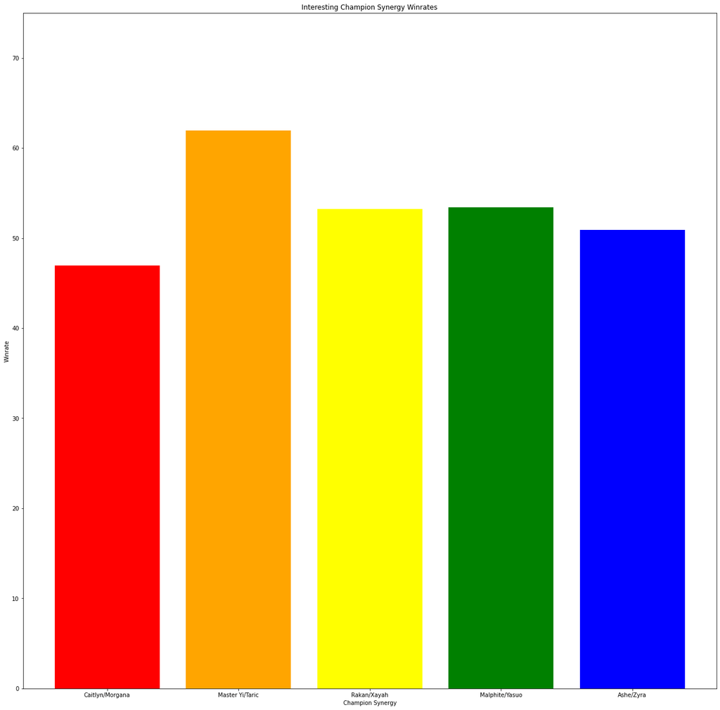

```python
# Grabs all the previously calculated synergy winrates for the corresponding synergies
sorted_winrate_keys_interesting = []
sorted_winrate_values_interesting = []
indicies = []
indicies.append(sorted_winrate_keys.index('Caitlyn/Morgana'))
indicies.append(sorted_winrate_keys.index('Master Yi/Taric'))
indicies.append(sorted_winrate_keys.index('Rakan/Xayah'))
indicies.append(sorted_winrate_keys.index('Malphite/Yasuo'))
indicies.append(sorted_winrate_keys.index('Ashe/Zyra'))
for i in indicies:
    sorted_winrate_keys_interesting.append(sorted_winrate_keys[i])
    sorted_winrate_values_interesting.append(sorted_winrate_values[i])

# Responsible for making the plot and making it look nice
fig, ax = plt.subplots(figsize=(22, 22))
ax.set_title('Interesting Champion Synergy Winrates')
plt.ylabel('Winrate')
plt.xlabel('Champion Synergy')
x = sorted_winrate_keys_interesting
y = sorted_winrate_values_interesting
ax.bar(x,y, color=['red', 'orange', 'yellow', 'green', 'blue'])
plt.ylim(ymin = 0, ymax= 75)
plt.show()
```

I will discuss the results in order below.

1. Generally, in League's history Caitlyn/Morgana is very strong and hard to play against. However, clearly they are not doing so well in season 7. This could be attributed to 2 reasons. First, Caitlyn and Morgana are both sitting at extremely low winrates of 47% and 48% respectively. Second, This is not an easy duo to pull off and is generally much more sucessful at higher ranks and pro play.
2. It is no suprise Master Yi and Taric have such a high winrate. Riot over the years has constantly had to make changes to the game to avoid cheese/funneling strategies because they can be so strong and so unfun to play against.
3. Since Rakan and Xayah came out season 7, I believe that if this data was from future seasons after people had more expereince with these champions the winrate will also climb to very high levels.
4. Malphite and Yasuo is about where I expect it to be.
5. Ashe and Zyra just like Caitlyn and Morgana are not very strong this season sitting at 47.7% and 49.9% winrates respectively and a hard duo to pull off but they must be either slightly stronger or easier than Caitlyn and Morgana as they can still sit slightly above 50% in season 7

These results are quite iteresting. Now lets take a look at these 5 synergies in context of average winrates vs gamelength. This could tell us if the synergy is strongest in the early game, not strongest in any part of the game, or strongest in the late game. In order to plot this I will make buckets for each minute and find the average winrate for each bucket. I can then plot this and do a linear regression. I opt to do a [weighted linear regression](https://en.wikipedia.org/wiki/Weighted_least_squares) instead of a standard linear regression because buckets with more datapoints need to have a stronger effect on the model.

## Champion and Synergy Winrates vs Gamelength

##### Grabbing Data

First I will grab all the corresponding data from our tidied dataframe and calculate the average winrate for each bucket and keep track of the weights for every synergy

```python
# Will hold the x and y values for each synergy. The x value is the gamelength bucket and the y value will be the
# average winrate for that bucket
x = [[], [], [], [], []]
y = [[], [], [], [] ,[]]

# Iterate through the entire dataframe row by row
for index, row in tidy_df.iterrows():
    # Avoids code duplication as we are doing the same thing for each player and team
    for team in range(1,3):
        for i in range (1,6):
            currChamp1 = tidy_df.at[index, 't' + str(team) + '_champ' + str(i)]

            # For each possible synergy we must update our dictionary
            for j in range(1,6):
                currChamp2 = tidy_df.at[index, 't' + str(team) + '_champ' + str(j)]

                # Make sure we do not do anything if we are talking about the same champion
                if (i != j):
                    # To account for the fact that only one of (i, j) and (j , i) is in synergy
                    if (currChamp1 > currChamp2):
                        temp = currChamp1
                        currChamp1 = currChamp2
                        currChamp2 = temp

                    # Only care about the 5 synergies below
                    indexy = -1
                    if (currChamp1 == 'Caitlyn' and currChamp2 == 'Morgana'):
                        indexy = 0
                    elif (currChamp1 == 'Master Yi' and currChamp2 == 'Taric'):
                        indexy = 1
                    elif (currChamp1 == 'Rakan' and currChamp2 == 'Xayah'):
                        indexy = 2
                    elif (currChamp1 == 'Malphite' and currChamp2 == 'Yasuo'):
                        indexy = 3
                    elif (currChamp1 == 'Ashe' and currChamp2 == 'Zyra'):
                        indexy = 4

                    if indexy != -1:
                        x[indexy].append(tidy_df.at[index, 'gameDuration'] - (tidy_df.at[index, 'gameDuration'] % 60))
                        # if the champions won the game
                        if (tidy_df.at[index, 'winner'] == team):
                            y[indexy].append(1)
                        # if the champions lost the game
                        else:
                            y[indexy].append(0)

# x and y currently hold every single individual datapoint and we want to change it to averages.
# avg will hold for each synergy a dictionary where the bucket points to a tuple of the number of games won and the
# number of games played. We will then simply use those values to find the average. We will also save the number of
# games played for each bucket to use as a weight for our linear regression
avg = [{}, {}, {}, {}, {}]
for index in range(0,5):
    for i,j in zip(x[index],y[index]):
        if i in avg[index]:
            # If won
            if j == 1:
                avg[index][i] = (avg[index][i][0] + 1, avg[index][i][1] + 1)
            # If lost
            if j == 0:
                avg[index][i] = (avg[index][i][0], avg[index][i][1] + 1)
        else:
            # If won
            if j == 1:
                avg[index][i] = (1,1)
            # If lost
            if j == 0:
                avg[index][i] = (0,1)

# Now we save the weights and calculate the averages
weight = [[],[],[],[],[]]
for index in range(0,5):
    for i in avg[index]:
        weight[index].append(avg[index][i][1])
        # finds win rate and scales to percentage
        avg[index][i] = (float(avg[index][i][0])/float(avg[index][i][1])) * 100
```

##### Data Visualization and Analysis of Individual Champions and Synergy Winrates vs Gamelength

Now I will simply calculate the linear regression for each synergy and plot the results. Note that because we are using a linear regression model we are assuming the data is normally distributed and homogeneous. We will check this afterwards.

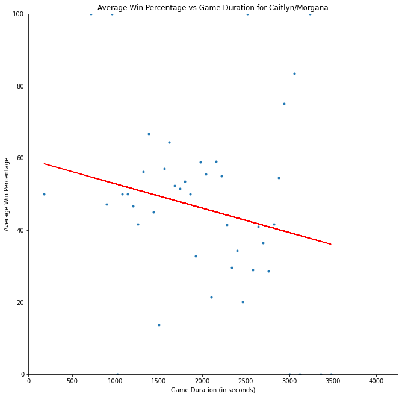

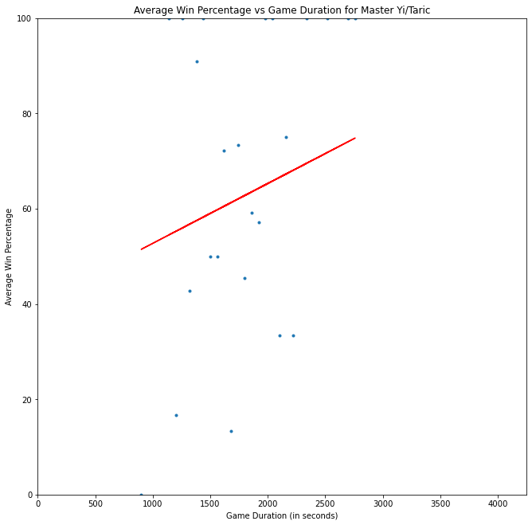

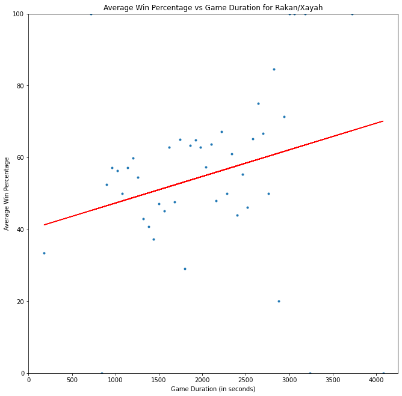

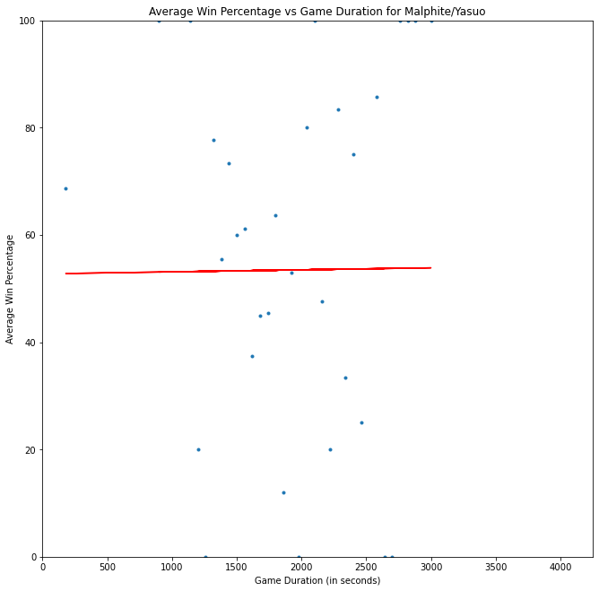

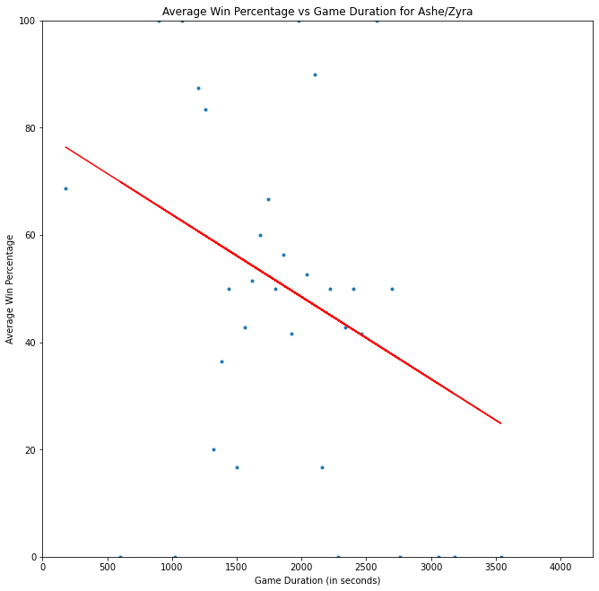

```python
# Indicies correspond to each of the synergies
hashDict = {0 : 'Caitlyn/Morgana', 1 : 'Master Yi/Taric', 2 : 'Rakan/Xayah', 3 : 'Malphite/Yasuo', 4 : 'Ashe/Zyra'}

x = []
y = []
linear_reg = []

# Gets a list of x and y values
for i in range(0,5):
    x.append(list(avg[i].keys()))
    y.append(list(avg[i].values()))

# Calulates the linear regression for each synergy
for index in range(0,5):
    X = [[i] for i in x[index]]
    lm = linear_model.LinearRegression()
    lm.fit(X,y[index], weight[index])
    linear_reg.append((X,lm))

for i in range(0,5):
    # Responsible for creating the scatter plot and making it look nicer
    plt.figure(figsize=(11,11))
    plt.plot(x[i], y[i], marker = '.', ls = 'none')
    plt.xlabel('Game Duration (in seconds)')
    plt.ylabel('Average Win Percentage')
    plt.ylim(ymin = 0, ymax= 100)
    plt.xlim(xmin = 0, xmax= 4250)
    plt.title(f'Average Win Percentage vs Game Duration for {hashDict[i]}')

    # Graphs the linear regression
    X = linear_reg[i][0]
    lm = linear_reg[i][1]
    plt.plot(X, lm.predict(X), color='red')

    plt.show()
```

Using the linear regressions we just found lets calculate how the win rate percentage changes as game duration increases by a minute for each synergy. We will print this below.

```python
for i in range (0,5):
    print(hashDict[i] + ' -> ' + str(linear_reg[i][1].coef_[0]*60))
```

```
Caitlyn/Morgana -> -0.4057658738336394
Master Yi/Taric -> 0.753788317420835
Rakan/Xayah -> 0.44434710861954163
Malphite/Yasuo -> 0.02246643150196649
Ashe/Zyra -> -0.919921573791471
```

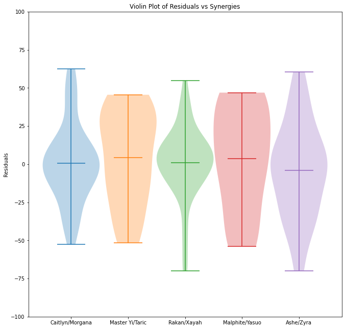

```python
residuals = [[], [], [], [], []]

for index in range (0,5):
    for i,j in zip(x[index],y[index]):
        residuals[index].append((j - linear_reg[index][1].predict([[i]]))[0])

# Responsible for making the plot and making it look nice
fig, ax = plt.subplots(figsize=(11, 11))
for i in range (0, 5):
    ax.violinplot(residuals[i], [i], widths = 1, showmeans = True)
ax.set_title('Violin Plot of Residuals vs Synergies')
plt.ylabel('Residuals')
plt.ylim(ymin=-100, ymax=100)
ax.set_xticks([0,1,2,3,4])
ax.set_xticklabels([hashDict[0], hashDict[1], hashDict[2], hashDict[3], hashDict[4]])
plt.show()
```

For Caitlyn/Morgana, Rakan/Xayah, and Ashe/Zyra the data is mostly normally distributed because there is one peak on each violin, the data is not skewed too far to one side, and the mean lies approximately in the center of the distribution. This means that are model fit the data reasonably well. However, for Master Yi/Taric and Malphite/Yasuo the data is not really normally distributed. This is likely because we did not have enough data.

## Conclusion

We first learned which champions were the best in season 7. Keeping this in the back of our mind as it is relevant to every synergy we investigate the worst and best synergies in season 7. Both of these were interesting but were season 7 specific. So we then investigated 5 of the most popular synergies in the League community listed below.

1. Caitlyn/Morgana
2. Master Yi/Taric
3. Rakan/Xayah
4. Malphite/Yasuo
5. Ashe/Zyra

Some potential future work I would like to do is use a much larger dataset with many seasons to avoid season dependency. Getting a dataset that also has rank information so we can see how synergies perform depending on rank (a problem I believe Caitlyn/Morgan suffer from). Getting more data on Master Yi/Taric and Malphite/Yasuo to build a better model.

Thanks for reading my tutorial. I hope you enjoyed it!